# Simulating infant and adult vocalization events

Anne S. Warlaumont

2023-12-04

(This is an R Markdown document. Markdown is a simple formatting syntax for authoring HTML, PDF, and MS Word documents. For more details on using R Markdown see http://rmarkdown.rstudio.com.)

# Set rthresh

```r
rthresh = 1
#rthresh = 5
```

## Simulate 5 minutes of infant vocal events

The approach is inspired by this paper: https://doi.org/10.1080/15427951.2004.10129088

Sampling from a binomial distribution where probability of vocalizing is multiplied at each 1 s time step by a random lognormal value (mu = 0.02 and sigma = 0.2), with an enforcement that the probability of vocalizing should stay between .002 and .2:

```r
sim_length = 5*60 # in 1-second time steps
p_voc = .02
voc_record = c()
for (t in 1:sim_length){
  voc_event = rbinom(1,1,p_voc)
  voc_record = c(voc_record,voc_event)
  p_voc_multiplier = rlnorm(1,meanlog = .02,sdlog = .2)
  p_voc = max(.002,min(.2,p_voc_multiplier * p_voc))
}
print(voc_record)
```

```
##   [1] 0 0 0 0 0 0 0 0 0 0 0 0 0 0 0 0 0 0 1 0 0 0 0 0 1 0 0 0 0 0 0 0 1 0 0 0 0
##  [38] 0 0 0 0 0 0 0 0 0 0 0 0 0 0 0 0 0 0 0 0 0 0 0 0 0 0 0 0 0 0 0 0 0 0 0 0 0
##  [75] 0 0 0 0 0 0 0 0 0 0 0 0 0 0 0 0 0 1 0 0 0 0 0 0 0 1 0 0 0 0 0 0 0 1 1 1 0
## [112] 0 0 0 0 1 1 1 0 0 0 0 0 0 0 0 0 0 0 0 0 0 1 0 0 0 0 1 1 1 0 1 1 0 0 0 0 0
## [149] 0 1 0 0 1 0 0 0 1 0 0 0 0 0 0 0 0 0 0 0 0 0 1 0 0 0 1 0 0 0 0 0 0 1 0 0 0
## [186] 0 0 0 0 0 0 0 0 0 0 0 0 0 0 0 0 0 0 0 0 0 0 0 0 0 0 0 1 0 0 0 0 1 1 0 0 0
## [223] 1 0 0 0 0 0 0 0 1 0 0 0 0 0 0 0 0 1 1 1 0 0 1 0 1 0 1 0 0 0 1 0 0 0 0 0 0
## [260] 1 0 0 0 0 0 0 0 0 0 0 0 0 0 0 0 0 1 0 0 0 0 0 0 0 0 0 0 0 0 0 0 0 0 0 0 1
## [297] 1 0 0 0
```

## Simulate 10 hr of infant vocalizations, with contingent adult vocal events also in the simulation

Have adults vocalize in a similar manner, but in such a way that their probability of vocalizing increases a bit each time the infant vocalizes and they do not vocalize if the infant is already vocalizing at that second:

```r
sim_length = 10*60*60 # 10 hours in 1-second time steps
p_i_voc = .02
p_a_voc = .02
i_voc_record = c()
a_voc_record = c()
for (t in 1:sim_length){

  i_voc_event = rbinom(1,1,p_i_voc)
  i_voc_record = c(i_voc_record,i_voc_event)
  p_i_voc_multiplier = rlnorm(1,meanlog = .02,sdlog = .2)
  p_i_voc = max(.002,min(.2,p_i_voc_multiplier * p_i_voc))

  if (i_voc_event==1){
    p_a_voc = p_a_voc*100
    a_voc_event = 0
  } else{
    a_voc_event = rbinom(1,1,p_a_voc)
  }
  a_voc_record = c(a_voc_record,a_voc_event)
  p_a_voc_multiplier = rlnorm(1,meanlog = .02,sdlog = .2)
  p_a_voc = max(.002,min(.2,p_a_voc_multiplier * p_a_voc))
}
print(i_voc_record[1:(5*60)])
```

```
##   [1] 0 0 0 0 0 0 0 0 0 0 0 0 0 0 0 0 0 0 0 0 0 0 0 0 0 0 0 0 0 0 0 0 0 0 0 0 0
##  [38] 0 0 0 0 0 0 0 0 0 1 0 0 0 0 0 1 0 0 0 0 0 0 0 0 0 0 0 0 0 0 0 0 0 0 0 0 0
##  [75] 0 0 0 0 0 0 0 0 0 0 0 1 1 0 0 0 0 0 0 0 0 1 0 0 0 0 0 0 1 0 0 0 0 1 0 0 0
## [112] 0 0 0 0 0 0 0 0 0 0 0 0 0 0 0 0 1 0 0 0 0 0 0 1 0 0 1 1 0 0 0 0 0 1 0 0 0
## [149] 0 0 0 0 0 0 0 0 0 0 0 0 0 0 0 0 0 0 1 0 1 0 0 0 0 0 0 0 0 0 0 0 0 1 1 0 0
## [186] 1 1 0 0 0 0 0 0 0 0 0 1 0 0 0 0 0 0 0 1 0 1 0 0 0 0 0 0 0 0 0 0 0 1 0 0 0
## [223] 1 0 0 0 0 0 1 0 0 0 0 1 0 0 0 0 1 0 0 1 0 0 0 0 0 0 0 0 1 0 0 0 0 0 0 0 0
## [260] 0 0 0 1 0 0 0 0 0 1 1 1 0 0 0 0 0 0 0 0 0 0 0 0 0 0 0 0 0 0 0 0 1 1 0 0 1
## [297] 1 0 1 0
```

```r
print(paste("total infant vocalization count: ",sum(i_voc_record)))
```

```
## [1] "total infant vocalization count:  4073"
```

```r
print(a_voc_record[1:(5*60)])
```

```
##   [1] 0 0 0 0 0 0 0 0 0 0 0 0 0 0 0 0 0 0 0 0 0 0 0 0 1 0 0 0 0 0 0 0 0 0 0 0 0
##  [38] 0 0 0 0 0 0 0 0 0 0 0 0 0 1 0 0 0 1 1 1 0 0 0 0 0 0 0 0 0 1 0 0 0 1 1 1 0
##  [75] 1 0 0 0 0 0 0 0 1 1 0 0 0 0 0 0 0 0 0 0 1 0 0 0 0 0 1 0 0 0 0 1 0 0 0 0 0
## [112] 0 1 0 0 1 0 0 0 0 0 0 0 0 0 0 0 0 1 1 0 1 1 0 0 0 0 0 0 0 1 0 0 0 0 0 0 0
## [149] 0 0 0 0 0 0 0 0 0 0 0 0 0 0 1 1 0 1 0 0 0 0 0 0 0 0 0 0 1 0 0 0 0 0 0 0 0
## [186] 0 0 1 0 0 0 0 1 1 0 1 0 1 0 0 0 0 0 0 0 0 0 0 0 0 0 0 0 0 0 0 0 0 0 0 0 0
## [223] 0 0 0 0 1 0 0 0 0 0 0 0 0 0 0 0 0 0 0 0 1 0 0 0 0 0 0 1 0 0 0 0 0 0 0 0 0
## [260] 0 0 0 0 0 0 0 0 0 0 0 0 0 0 0 1 0 1 0 0 0 0 0 0 1 0 0 0 0 1 0 0 0 0 0 0 0
## [297] 0 1 0 0
```

```r
print(paste("total adult vocalization count: ",sum(a_voc_record)))
```

```
## [1] "total adult vocalization count:  5148"
```

## Which infant vocalizations were followed by adult responses?

Calculate how many infant vocalizations were followed within rthresh s by an adult vocalization

```r
atoi_r_record = c()
for (t in 1:(sim_length-rthresh)){
  if (i_voc_record[t] == 1){
    if (sum(a_voc_record[(t+1):(t+rthresh)])>0){
      atoi_r_record = c(atoi_r_record,1)
    }else{
      atoi_r_record = c(atoi_r_record,0)
    }
  }else{
    atoi_r_record = c(atoi_r_record,NA)
  }
}
atoi_r_count = sum(atoi_r_record,na.rm=TRUE)
print(paste("response window: ",rthresh))
```

```
## [1] "response window:  1"
```

```r
print(atoi_r_record[1:(5*60)])
```

```
##   [1] NA NA NA NA NA NA NA NA NA NA NA NA NA NA NA NA NA NA NA NA NA NA NA NA NA
##  [26] NA NA NA NA NA NA NA NA NA NA NA NA NA NA NA NA NA NA NA NA NA  0 NA NA NA
##  [51] NA NA  0 NA NA NA NA NA NA NA NA NA NA NA NA NA NA NA NA NA NA NA NA NA NA
##  [76] NA NA NA NA NA NA NA NA NA NA  0  0 NA NA NA NA NA NA NA NA  0 NA NA NA NA
## [101] NA NA  0 NA NA NA NA  0 NA NA NA NA NA NA NA NA NA NA NA NA NA NA NA NA NA
## [126] NA NA  1 NA NA NA NA NA NA  0 NA NA  0  0 NA NA NA NA NA  0 NA NA NA NA NA
## [151] NA NA NA NA NA NA NA NA NA NA NA NA NA NA NA NA  0 NA  0 NA NA NA NA NA NA
## [176] NA NA NA NA NA NA  0  0 NA NA  0  1 NA NA NA NA NA NA NA NA NA  1 NA NA NA
## [201] NA NA NA NA  0 NA  0 NA NA NA NA NA NA NA NA NA NA NA  0 NA NA NA  0 NA NA
## [226] NA NA NA  0 NA NA NA NA  0 NA NA NA NA  0 NA NA  1 NA NA NA NA NA NA NA NA
## [251]  0 NA NA NA NA NA NA NA NA NA NA NA  0 NA NA NA NA NA  0  0  0 NA NA NA NA
## [276] NA NA NA NA NA NA NA NA NA NA NA NA NA NA NA NA  0  0 NA NA  0  1 NA  0 NA
```

```r
print(paste("total adult response to infant count:",atoi_r_count))
```

```
## [1] "total adult response to infant count: 714"
```

## Which adult vocalizations were followed by infant responses?

```r
itoa_r_record = c()
for (t in 1:(sim_length-rthresh)){
  if (a_voc_record[t] == 1){
    if (sum(i_voc_record[(t+1):(t+rthresh)])>0){
      itoa_r_record = c(itoa_r_record,1)
    }else{
      itoa_r_record = c(itoa_r_record,0)
    }
  }else{
    itoa_r_record = c(itoa_r_record,NA)
  }
}
itoa_r_count = sum(itoa_r_record,na.rm=TRUE)
print(paste("response window: ",rthresh))
```

```
## [1] "response window:  1"
```

```r
print(itoa_r_record[1:(5*60)])
```

```
##   [1] NA NA NA NA NA NA NA NA NA NA NA NA NA NA NA NA NA NA NA NA NA NA NA NA  0
##  [26] NA NA NA NA NA NA NA NA NA NA NA NA NA NA NA NA NA NA NA NA NA NA NA NA NA
##  [51]  0 NA NA NA  0  0  0 NA NA NA NA NA NA NA NA NA  0 NA NA NA  0  0  0 NA  0
##  [76] NA NA NA NA NA NA NA  0  0 NA NA NA NA NA NA NA NA NA NA  1 NA NA NA NA NA
## [101]  0 NA NA NA NA  0 NA NA NA NA NA NA  0 NA NA  0 NA NA NA NA NA NA NA NA NA
## [126] NA NA NA  0  0 NA  0  0 NA NA NA NA NA NA NA  0 NA NA NA NA NA NA NA NA NA
## [151] NA NA NA NA NA NA NA NA NA NA NA NA  0  0 NA  1 NA NA NA NA NA NA NA NA NA
## [176] NA  0 NA NA NA NA NA NA NA NA NA NA  0 NA NA NA NA  0  0 NA  1 NA  0 NA NA
## [201] NA NA NA NA NA NA NA NA NA NA NA NA NA NA NA NA NA NA NA NA NA NA NA NA NA
## [226] NA  0 NA NA NA NA NA NA NA NA NA NA NA NA NA NA NA  0 NA NA NA NA NA NA  1
## [251] NA NA NA NA NA NA NA NA NA NA NA NA NA NA NA NA NA NA NA NA NA NA NA NA  0
## [276] NA  0 NA NA NA NA NA NA  0 NA NA NA NA  0 NA NA NA NA NA NA NA NA  1 NA NA
```

```r
print(paste("total infant response to count:",itoa_r_count))
```

```
## [1] "total infant response to count: 584"
```

## Get infant inter-vocalization intervals and whether they are with response or without response steps, and the median and 90th percentile values for the wr and wor steps. Exclude steps (setting wr to NA in those cases) where the infant ivi was <= rthresh (because then the adult couldn’t have responded, because they were restricted from overlapping an infant voc).

```r
i_ivi_record = c()
i_ivi_wr_record = c()
i1 = NA
i2 = NA
for (t in 1:sim_length){
  if (is.na(i1) & i_voc_record[t]==1){
    i1 = t
  } else if (i_voc_record[t]==1){

    i2 = t
    ivi = i2-i1
    i_ivi_record = c(i_ivi_record,ivi)

    if (ivi<=rthresh){
      i_ivi_wr_record = c(i_ivi_wr_record,NA)
    }else if (atoi_r_record[i1]==1){
      i_ivi_wr_record = c(i_ivi_wr_record,1)
    }else{
      i_ivi_wr_record = c(i_ivi_wr_record,0)
    }

    i1 = i2
  }
}
print(i_ivi_record[1:(5*60)])
```

```
##   [1]  6 33  1  9  7  5 20  7  3  1  6 22  2 13  1  3  1 10  8  2 12  4  6  5  5
##  [26]  3  9 12  6  1  1 21  1  3  1  2  7  7  4  9 51  7  2 17  4  1  9 26 16 25
##  [51]  3  5  5  5  1 16 11 21 35  4  9 14  3  8 11  1  6  2  7 18 11  4 13 14  8
##  [76]  2  2  1  2  5  3  3  8  4  2  3  4  1 20 12  1  3  1  6  1  3 21 17  2  4
## [101]  2 14  1 10  1  1  4  3  2  6  2  7  2  1  1  1  1  8  1  2  1  1  3  1  3
## [126]  4  2  5  4  3  8  9 14  6  7  2  5 10  5  4  2 10  5  1  3  9  1  7 21 10
## [151]  6 21  2  4 19  2  6  3  1  7  4  1  1  3  5  1 18  7  8 18 14  9  1  1 29
## [176]  2  3 23  1 14 66  6  5 11 14  2  2  2  4  5  7  3 11  4  3  2  1 14 10 24
## [201]  2  2  6 14  1  4  3  2  9  2  8  2  9  1  3  1 15  1 14  2  3  6 10  3  5
## [226]  4  3  4 19  7  2  1  1 16  1  7  2 21 11 51 20  4  2  1 28  1  2 21  3  2
## [251]  7  4  1 11  1 15  3  4 11  5  3  3 11  7  1  5  3  5 18 17  7  2 18 18  9
## [276]  2  1 10  2 15  1  6  7  1  2  5  7  8  5  3 11  6  5  2  1  5  8 13  1  7
```

```r
print(i_ivi_wr_record[1:(5*60)])
```

```
##   [1]  0  0 NA  0  0  0  0  1  0 NA  0  0  0  0 NA  0 NA  1  1  0  0  0  0  0  0
##  [26]  0  1  0  0 NA NA  0 NA  0 NA  1  0  0  0  0  0  1  0  0  0 NA  0  1  0  0
##  [51]  0  0  0  0 NA  0  1  1  0  1  1  0  0  0  0 NA  1  0  0  0  0  0  1  0  1
##  [76]  0  0 NA  1  1  1  0  0  1  0  0  0 NA  0  0 NA  0 NA  1 NA  1  0  0  1  0
## [101]  0  0 NA  0 NA NA  1  1  0  0  0  0  0 NA NA NA NA  0 NA  0 NA NA  0 NA  0
## [126]  0  0  0  0  0  0  0  0  0  0  0  0  0  1  0  0  0  0 NA  0  0 NA  1  1  0
## [151]  0  0  0  0  0  0  0  1 NA  1  1 NA NA  0  0 NA  0  1  0  0  0  1 NA NA  1
## [176]  0  1  0 NA  0  0  0  0  0  0  0  0  0  0  0  0  1  1  0  0  0 NA  1  1  0
## [201]  0  1  0  0 NA  0  0  0  0  0  0  1  1 NA  0 NA  0 NA  0  0  0  0  0  0  0
## [226]  1  1  1  1  0  0 NA NA  0 NA  0  0  0  0  0  0  1  0 NA  0 NA  0  0  0  0
## [251]  0  0 NA  0 NA  0  0  0  0  1  0  0  0  0 NA  0  1  0  0  1  0  1  0  0  0
## [276]  0 NA  1  0  0 NA  0  0 NA  1  0  0  0  0  0  0  0  0  0 NA  1  0  0 NA  1
```

```r
i_ivi_minlength_record = i_ivi_record[i_ivi_record>rthresh+1]
i_ivi_minlength_wr_record = i_ivi_wr_record[i_ivi_record>rthresh+1]
i_ivi_wr_median = median(i_ivi_minlength_record[i_ivi_minlength_wr_record==1])
i_ivi_wor_median = median(i_ivi_minlength_record[i_ivi_minlength_wr_record!=1])
i_ivi_wr_90pct = quantile(i_ivi_minlength_record[i_ivi_minlength_wr_record==1],probs=.9,na.rm=TRUE)
i_ivi_wor_90pct = quantile(i_ivi_minlength_record[i_ivi_minlength_wr_record!=1],probs=.9,na.rm=TRUE)
print(i_ivi_wr_median)
```

```
## [1] 8
```

```r
print(i_ivi_wor_median)
```

```
## [1] 7
```

```r
print(i_ivi_wr_90pct)
```

```
##  90%
## 22.9
```

```r
print(i_ivi_wor_90pct)
```

```
## 90%
##  23
```

## Perform uncontrolled analysis testing whether WR IVIs are shorter than WOR IVIs

```r
i_ivi_wr_fit = lm(scale(i_ivi_record)~i_ivi_wr_record)
summary(i_ivi_wr_fit)
```

```
##
## Call:
## lm(formula = scale(i_ivi_record) ~ i_ivi_wr_record)
##
## Residuals:
##     Min      1Q  Median      3Q     Max
## -0.6377 -0.5373 -0.3063  0.1326 12.7648
##
## Coefficients:
##                 Estimate Std. Error t value Pr(>|t|)
## (Intercept)      0.11168    0.02003   5.575 2.67e-08 ***
## i_ivi_wr_record -0.02330    0.04409  -0.528    0.597
## ---
## Signif. codes:  0 '***' 0.001 '**' 0.01 '*' 0.05 '.' 0.1 ' ' 1
##
## Residual standard error: 1.05 on 3457 degrees of freedom
##   (613 observations deleted due to missingness)
## Multiple R-squared:  8.077e-05,  Adjusted R-squared:  -0.0002085
## F-statistic: 0.2792 on 1 and 3457 DF,  p-value: 0.5972
```

```r
i_ivi_wr_log_fit = lm(scale(log(i_ivi_record))~i_ivi_wr_record)
summary(i_ivi_wr_log_fit)
```

```
##
## Call:
## lm(formula = scale(log(i_ivi_record)) ~ i_ivi_wr_record)
##
## Residuals:
##      Min       1Q   Median       3Q      Max
## -1.17150 -0.75475 -0.09218  0.57040  3.13752
##
## Coefficients:
##                 Estimate Std. Error t value Pr(>|t|)
## (Intercept)      0.26660    0.01578   16.89   <2e-16 ***
## i_ivi_wr_record  0.02917    0.03473    0.84    0.401
## ---
## Signif. codes:  0 '***' 0.001 '**' 0.01 '*' 0.05 '.' 0.1 ' ' 1
##
## Residual standard error: 0.8267 on 3457 degrees of freedom
##   (613 observations deleted due to missingness)
## Multiple R-squared:  0.000204,   Adjusted R-squared:  -8.519e-05
## F-statistic: 0.7055 on 1 and 3457 DF,  p-value: 0.401
```

## Find and plot the relationship between the current infant IVI and the previous infant IVI

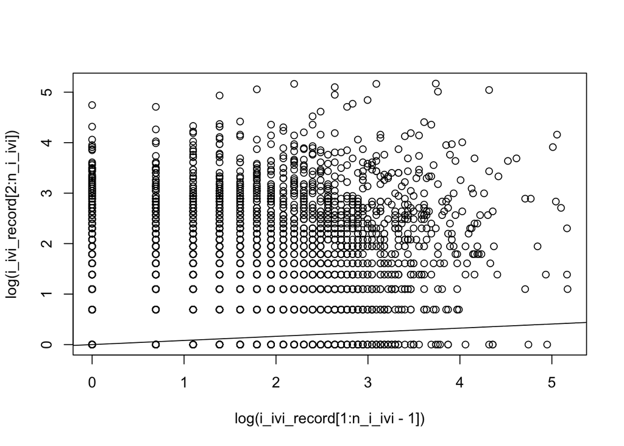

```r
n_i_ivi = length(i_ivi_record)
plot(log(i_ivi_record[1:n_i_ivi-1]),log(i_ivi_record[2:n_i_ivi]))
i_ivi_fit = lm(scale(log(i_ivi_record[2:n_i_ivi]))~scale(log(i_ivi_record[1:n_i_ivi-1])))
#i_ivi_fit = lm(scale(log(i_ivi_record[4:n_i_ivi]))~scale(log(i_ivi_record[1:(n_i_ivi-3)]))+scale(log(i_ivi_record[2:(n_i_ivi-2)]))+scale(log(i_ivi_record[3:(n_i_ivi-1)])))
abline(i_ivi_fit)
```

```r
summary(i_ivi_fit)
```

```
##
## Call:
## lm(formula = scale(log(i_ivi_record[2:n_i_ivi])) ~ scale(log(i_ivi_record[1:n_i_ivi -
##     1])))
##
## Residuals:
##     Min      1Q  Median      3Q     Max
## -1.7991 -0.8040  0.0002  0.7086  3.3524
##
## Coefficients:
##                                          Estimate Std. Error t value Pr(>|t|)
## (Intercept)                             8.654e-16  1.562e-02   0.000        1
## scale(log(i_ivi_record[1:n_i_ivi - 1])) 8.177e-02  1.562e-02   5.233 1.75e-07
##
## (Intercept)
## scale(log(i_ivi_record[1:n_i_ivi - 1])) ***
## ---
## Signif. codes:  0 '***' 0.001 '**' 0.01 '*' 0.05 '.' 0.1 ' ' 1
##
## Residual standard error: 0.9968 on 4069 degrees of freedom
## Multiple R-squared:  0.006686,   Adjusted R-squared:  0.006442
## F-statistic: 27.39 on 1 and 4069 DF,  p-value: 1.749e-07
```

## Get the residuals of of that fit, indicating if the current infant IVI is longer or shorter than expected given the previous infant IVI

```r
i_ivi_res = resid(i_ivi_fit)
```

# See if the residuals of the prediction of current IVI based on previous IVI show a pattern where wr IVIs are shorter than wor IVIs controlling for the persistence of IVI

```r
i_ivi_res_fit = lm(scale(i_ivi_res[1:length(i_ivi_res-1)])~scale(i_ivi_wr_record[2:length(i_ivi_wr_record-1)]),na.action=na.omit)
#i_ivi_res_fit = lm(scale(i_ivi_res[1:length(i_ivi_res-1)])~scale(i_ivi_wr_record[4:length(i_ivi_wr_record-1)]),na.action=na.omit)
summary(i_ivi_res_fit)
```

```
##
## Call:
## lm(formula = scale(i_ivi_res[1:length(i_ivi_res - 1)]) ~ scale(i_ivi_wr_record[2:length(i_ivi_wr_record -
##     1)]), na.action = na.omit)
##
## Residuals:
##      Min       1Q   Median       3Q      Max
## -1.34584 -0.68280 -0.04255  0.53793  3.09867
##
## Coefficients:
##                                                       Estimate Std. Error
## (Intercept)                                            0.27229    0.01406
## scale(i_ivi_wr_record[2:length(i_ivi_wr_record - 1)])  0.01435    0.01406
##                                                       t value Pr(>|t|)
## (Intercept)                                            19.365   <2e-16 ***
## scale(i_ivi_wr_record[2:length(i_ivi_wr_record - 1)])   1.021    0.307
## ---
## Signif. codes:  0 '***' 0.001 '**' 0.01 '*' 0.05 '.' 0.1 ' ' 1
##
## Residual standard error: 0.8268 on 3456 degrees of freedom
##   (613 observations deleted due to missingness)
## Multiple R-squared:  0.0003013,  Adjusted R-squared:  1.207e-05
## F-statistic: 1.042 on 1 and 3456 DF,  p-value: 0.3075
```

## Have infant vocalizations increase in probability following an adult response

```r
sim_length = 10*60*60 # 10 hours in 1-second time steps
p_i_voc = .02
p_a_voc = .02
i_voc_record = c()
a_voc_record = c()
atoi_r_record = c()
itoa_r_record = c()
for (t in 1:sim_length){

  i_voc_event = rbinom(1,1,p_i_voc)
  i_voc_record = c(i_voc_record,i_voc_event)
  p_i_voc_multiplier = rlnorm(1,meanlog = .02,sdlog = .2)
  p_i_voc = max(.002,min(.2,p_i_voc_multiplier * p_i_voc))

  if (i_voc_event==1){
    p_a_voc = max(.002,min(.2,p_a_voc*100))
    a_voc_event = 0
  } else{
    a_voc_event = rbinom(1,1,p_a_voc)
  }
  a_voc_record = c(a_voc_record,a_voc_event)
  p_a_voc_multiplier = rlnorm(1,meanlog = .02,sdlog = .2)
  p_a_voc = max(.002,min(.2,p_a_voc_multiplier * p_a_voc))

  if (t>rthresh){

    # Record when the adult responded to the infant
    if (i_voc_record[t-rthresh] == 1){
      if (sum(a_voc_record[(t-rthresh+1):t])>0){
        atoi_r_record = c(atoi_r_record,1)
      }else{
        atoi_r_record = c(atoi_r_record,0)
      }
    }else{
      atoi_r_record = c(atoi_r_record,NA)
    }

    # Record when the infant responded to the adult
    if (a_voc_record[t-rthresh] == 1){
      if (sum(i_voc_record[(t-rthresh+1):t])>0){
        itoa_r_record = c(itoa_r_record,1)
      }else{
        itoa_r_record = c(itoa_r_record,0)
      }
    }else{
      itoa_r_record = c(itoa_r_record,NA)
    }

  }

  if (t>rthresh){
    if (!is.na(atoi_r_record[t-rthresh])){
       if (atoi_r_record[t-rthresh]==1){
         p_i_voc = max(.002,min(.2,p_i_voc*100))

       }
    }
  }

}

print(i_voc_record[1:(5*60)])
```

```
##   [1] 0 0 0 0 0 0 0 0 0 0 0 0 0 0 0 0 0 0 1 1 0 0 0 0 0 0 1 0 0 0 0 0 1 0 0 0 0
##  [38] 0 0 0 0 0 0 0 0 0 0 0 0 0 0 0 0 0 0 0 0 0 0 0 0 0 0 0 0 0 0 0 0 0 0 0 0 0
##  [75] 0 0 0 0 0 0 1 0 0 0 0 0 0 0 0 0 0 0 0 0 1 1 0 0 0 0 0 0 0 0 0 0 0 0 0 0 0
## [112] 0 0 0 0 0 0 0 0 0 0 0 0 0 0 0 0 1 0 0 0 0 0 0 0 0 0 0 0 0 1 0 0 0 0 0 0 0
## [149] 0 1 1 0 0 0 0 0 0 0 0 1 0 0 0 0 0 0 0 0 0 0 0 0 1 1 0 0 0 1 1 0 0 0 0 0 0
## [186] 0 1 0 0 1 0 0 0 0 1 0 0 0 0 0 0 0 0 1 0 0 0 0 0 0 0 0 0 0 0 0 0 0 0 0 1 0
## [223] 0 0 0 1 0 1 0 0 0 0 0 0 0 1 0 0 0 0 0 0 1 0 0 0 0 1 0 1 0 1 0 0 0 0 0 0 0
## [260] 0 0 1 1 0 0 1 1 0 0 0 0 0 0 0 0 0 0 0 0 0 0 0 0 0 0 0 0 0 1 0 1 0 1 0 1 0
## [297] 0 0 1 0
```

```r
print(paste("total infant vocalization count: ",sum(i_voc_record)))
```

```
## [1] "total infant vocalization count:  4820"
```

```r
print(a_voc_record[1:(5*60)])
```

```
##   [1] 0 0 0 0 0 0 0 0 0 0 0 0 0 0 0 0 0 0 0 0 0 0 0 0 1 0 0 0 0 0 0 0 0 0 0 0 0
##  [38] 0 0 0 0 0 0 0 0 0 0 0 0 0 0 0 0 0 0 0 0 0 0 0 0 0 0 0 0 0 0 0 0 0 0 0 0 0
##  [75] 0 0 0 0 0 0 0 0 0 0 0 0 0 0 0 0 0 0 0 0 0 0 0 0 1 0 0 0 0 0 0 1 0 0 0 0 0
## [112] 0 0 0 0 0 0 0 0 0 0 0 0 0 1 0 0 0 0 0 0 0 0 0 0 0 0 0 0 0 0 0 0 0 0 0 0 1
## [149] 0 0 0 0 1 0 0 1 1 0 0 0 0 1 1 0 0 0 0 0 1 0 1 0 0 0 1 0 1 0 0 1 1 0 0 1 1
## [186] 0 0 0 0 0 1 0 0 0 0 0 0 1 0 0 0 0 0 0 1 1 1 0 0 0 1 0 0 0 0 0 0 1 0 0 0 0
## [223] 0 0 0 0 0 0 1 0 0 0 0 0 0 0 0 0 0 0 0 0 0 0 0 0 0 0 1 0 0 0 0 0 0 0 0 1 0
## [260] 0 0 0 0 0 0 0 0 0 0 1 0 0 0 1 0 0 0 0 0 0 0 0 0 1 0 1 0 1 0 0 0 0 0 0 0 0
## [297] 0 1 0 0
```

```r
print(paste("total adult vocalization count: ",sum(a_voc_record)))
```

```
## [1] "total adult vocalization count:  4992"
```

```r
print(paste("response window: ",rthresh))
```

```
## [1] "response window:  1"
```

```r
atoi_r_count = sum(atoi_r_record,na.rm=TRUE)
print(atoi_r_record[1:(5*60)])
```

```
##   [1] NA NA NA NA NA NA NA NA NA NA NA NA NA NA NA NA NA NA  0  0 NA NA NA NA NA
##  [26] NA  0 NA NA NA NA NA  0 NA NA NA NA NA NA NA NA NA NA NA NA NA NA NA NA NA
##  [51] NA NA NA NA NA NA NA NA NA NA NA NA NA NA NA NA NA NA NA NA NA NA NA NA NA
##  [76] NA NA NA NA NA  0 NA NA NA NA NA NA NA NA NA NA NA NA NA  0  0 NA NA NA NA
## [101] NA NA NA NA NA NA NA NA NA NA NA NA NA NA NA NA NA NA NA NA NA NA NA NA NA
## [126] NA NA  0 NA NA NA NA NA NA NA NA NA NA NA NA  0 NA NA NA NA NA NA NA NA  0
## [151]  0 NA NA NA NA NA NA NA NA  0 NA NA NA NA NA NA NA NA NA NA NA NA  0  1 NA
## [176] NA NA  0  1 NA NA NA NA NA NA NA  0 NA NA  1 NA NA NA NA  0 NA NA NA NA NA
## [201] NA NA NA  1 NA NA NA NA NA NA NA NA NA NA NA NA NA NA NA NA  0 NA NA NA NA
## [226]  0 NA  1 NA NA NA NA NA NA NA  0 NA NA NA NA NA NA  0 NA NA NA NA  1 NA  0
## [251] NA  0 NA NA NA NA NA NA NA NA NA  0  0 NA NA  0  0 NA NA NA NA NA NA NA NA
## [276] NA NA NA NA NA NA NA NA NA NA NA NA NA  0 NA  0 NA  0 NA  0 NA NA NA  0 NA
```

```r
print(paste("total adult response to infant count:",atoi_r_count))
```

```
## [1] "total adult response to infant count: 748"
```

```r
itoa_r_count = sum(itoa_r_record,na.rm=TRUE)
print(itoa_r_record[1:(5*60)])
```

```
##   [1] NA NA NA NA NA NA NA NA NA NA NA NA NA NA NA NA NA NA NA NA NA NA NA NA  0
##  [26] NA NA NA NA NA NA NA NA NA NA NA NA NA NA NA NA NA NA NA NA NA NA NA NA NA
##  [51] NA NA NA NA NA NA NA NA NA NA NA NA NA NA NA NA NA NA NA NA NA NA NA NA NA
##  [76] NA NA NA NA NA NA NA NA NA NA NA NA NA NA NA NA NA NA NA NA NA NA NA  0 NA
## [101] NA NA NA NA NA  0 NA NA NA NA NA NA NA NA NA NA NA NA NA NA NA NA NA NA  0
## [126] NA NA NA NA NA NA NA NA NA NA NA NA NA NA NA NA NA NA NA NA NA NA  0 NA NA
## [151] NA NA  0 NA NA  0  0 NA NA NA NA  0  0 NA NA NA NA NA  0 NA  0 NA NA NA  0
## [176] NA  1 NA NA  0  0 NA NA  0  0 NA NA NA NA NA  0 NA NA NA NA NA NA  0 NA NA
## [201] NA NA NA NA  0  0  0 NA NA NA  0 NA NA NA NA NA NA  0 NA NA NA NA NA NA NA
## [226] NA NA NA  0 NA NA NA NA NA NA NA NA NA NA NA NA NA NA NA NA NA NA NA  1 NA
## [251] NA NA NA NA NA NA NA  0 NA NA NA NA NA NA NA NA NA NA NA  0 NA NA NA  0 NA
## [276] NA NA NA NA NA NA NA NA  0 NA  0 NA  1 NA NA NA NA NA NA NA NA NA  1 NA NA
```

```r
print(paste("total infant response to adult count:",itoa_r_count))
```

```
## [1] "total infant response to adult count: 699"
```

## Which infant vocalizations were followed by adult responses?

Calculate how many infant vocalizations were followed within rthresh s by an adult vocalization

```r
atoi_r_record = c()
for (t in 1:(sim_length-rthresh)){
  if (i_voc_record[t] == 1){
    if (sum(a_voc_record[(t+1):(t+rthresh)])>0){
      atoi_r_record = c(atoi_r_record,1)
    }else{
      atoi_r_record = c(atoi_r_record,0)
    }
  }else{
    atoi_r_record = c(atoi_r_record,NA)
  }
}
atoi_r_count = sum(atoi_r_record,na.rm=TRUE)
print(paste("response window: ",rthresh))
```

```
## [1] "response window:  1"
```

```r
print(atoi_r_record[1:(5*60)])
```

```
##   [1] NA NA NA NA NA NA NA NA NA NA NA NA NA NA NA NA NA NA  0  0 NA NA NA NA NA
##  [26] NA  0 NA NA NA NA NA  0 NA NA NA NA NA NA NA NA NA NA NA NA NA NA NA NA NA
##  [51] NA NA NA NA NA NA NA NA NA NA NA NA NA NA NA NA NA NA NA NA NA NA NA NA NA
##  [76] NA NA NA NA NA  0 NA NA NA NA NA NA NA NA NA NA NA NA NA  0  0 NA NA NA NA
## [101] NA NA NA NA NA NA NA NA NA NA NA NA NA NA NA NA NA NA NA NA NA NA NA NA NA
## [126] NA NA  0 NA NA NA NA NA NA NA NA NA NA NA NA  0 NA NA NA NA NA NA NA NA  0
## [151]  0 NA NA NA NA NA NA NA NA  0 NA NA NA NA NA NA NA NA NA NA NA NA  0  1 NA
## [176] NA NA  0  1 NA NA NA NA NA NA NA  0 NA NA  1 NA NA NA NA  0 NA NA NA NA NA
## [201] NA NA NA  1 NA NA NA NA NA NA NA NA NA NA NA NA NA NA NA NA  0 NA NA NA NA
## [226]  0 NA  1 NA NA NA NA NA NA NA  0 NA NA NA NA NA NA  0 NA NA NA NA  1 NA  0
## [251] NA  0 NA NA NA NA NA NA NA NA NA  0  0 NA NA  0  0 NA NA NA NA NA NA NA NA
## [276] NA NA NA NA NA NA NA NA NA NA NA NA NA  0 NA  0 NA  0 NA  0 NA NA NA  0 NA
```

```r
print(paste("total adult response to infant count:",atoi_r_count))
```

```
## [1] "total adult response to infant count: 748"
```

## Which adult vocalizations were followed by infant responses?

```r
itoa_r_record = c()
for (t in 1:(sim_length-rthresh)){
  if (a_voc_record[t] == 1){
    if (sum(i_voc_record[(t+1):(t+rthresh)])>0){
      itoa_r_record = c(itoa_r_record,1)
    }else{
      itoa_r_record = c(itoa_r_record,0)
    }
  }else{
    itoa_r_record = c(itoa_r_record,NA)
  }
}
itoa_r_count = sum(itoa_r_record,na.rm=TRUE)
print(paste("response window: ",rthresh))
```

```
## [1] "response window:  1"
```

```r
print(itoa_r_record[1:(5*60)])
```

```
##   [1] NA NA NA NA NA NA NA NA NA NA NA NA NA NA NA NA NA NA NA NA NA NA NA NA  0
##  [26] NA NA NA NA NA NA NA NA NA NA NA NA NA NA NA NA NA NA NA NA NA NA NA NA NA
##  [51] NA NA NA NA NA NA NA NA NA NA NA NA NA NA NA NA NA NA NA NA NA NA NA NA NA
##  [76] NA NA NA NA NA NA NA NA NA NA NA NA NA NA NA NA NA NA NA NA NA NA NA  0 NA
## [101] NA NA NA NA NA  0 NA NA NA NA NA NA NA NA NA NA NA NA NA NA NA NA NA NA  0
## [126] NA NA NA NA NA NA NA NA NA NA NA NA NA NA NA NA NA NA NA NA NA NA  0 NA NA
## [151] NA NA  0 NA NA  0  0 NA NA NA NA  0  0 NA NA NA NA NA  0 NA  0 NA NA NA  0
## [176] NA  1 NA NA  0  0 NA NA  0  0 NA NA NA NA NA  0 NA NA NA NA NA NA  0 NA NA
## [201] NA NA NA NA  0  0  0 NA NA NA  0 NA NA NA NA NA NA  0 NA NA NA NA NA NA NA
## [226] NA NA NA  0 NA NA NA NA NA NA NA NA NA NA NA NA NA NA NA NA NA NA NA  1 NA
## [251] NA NA NA NA NA NA NA  0 NA NA NA NA NA NA NA NA NA NA NA  0 NA NA NA  0 NA
## [276] NA NA NA NA NA NA NA NA  0 NA  0 NA  1 NA NA NA NA NA NA NA NA NA  1 NA NA
```

```r
print(paste("total infant response to count:",itoa_r_count))
```

```
## [1] "total infant response to count: 699"
```

## Get infant inter-vocalization intervals and whether they are with response or without response steps, and the median and 90th percentile values for the wr and wor steps. Exclude steps (setting wr to NA in those cases) where the infant ivi was <= rthresh (because then the adult couldn’t have responded, because they were restricted from overlapping an infant voc).

```r
i_ivi_record = c()
i_ivi_wr_record = c()
i1 = NA
i2 = NA
for (t in 1:sim_length){
  if (is.na(i1) & i_voc_record[t]==1){
    i1 = t
  } else if (i_voc_record[t]==1){

    i2 = t
    ivi = i2-i1
    i_ivi_record = c(i_ivi_record,ivi)

    if (ivi<=rthresh){
      i_ivi_wr_record = c(i_ivi_wr_record,NA)
    }else if (atoi_r_record[i1]==1){
      i_ivi_wr_record = c(i_ivi_wr_record,1)
    }else{
      i_ivi_wr_record = c(i_ivi_wr_record,0)
    }

    i1 = i2
  }
}
print(i_ivi_record[1:(5*60)])
```

```
##   [1]  1  7  6 48 14  1 32 13  9  1  9 13  1  4  1  8  3  5  9 17  5  2  8  7  5
##  [26]  2  2 10  1  3  1 22  2  2  2  4  5  5 12  3  2  7  3  1  9  5  6  5  1 23
##  [51]  6  2  1  2  1  2  3  1  4  9  6 15  6 55 26  5  2 23  9  1  3 10  2  5  2
##  [76]  2 13  4 13  3  4  6 11  2  9  1 12 16  7  2  5 24  8  6 14 14  4 22  2  3
## [101]  7 15 12 14 15 25  5  2 12 11  5  2  2  7  2  5  4 12 12  4  4 14  4 10  1
## [126] 46 10  4 11 30  1  1  3  1  5 17  1 83 30  4  1  1  3 11  3  2  7  1  3  9
## [151]  6  1  5 22 25  6  3  3  2  1 17 21  1  3 12  2  2  1  2  1  3  6  4 11  6
## [176] 21  3  3  2  8 17 23  9  2  6 12 10  6  1  7  6 11  3  3  1  9  5 10  5  3
## [201]  1  6  3  8  5  5  5  6  2  1 10  6  2  1  1 13  3  2 13  3 57  3  3 10  2
## [226]  7  2 11  5  2  1  2 23  1  1  1 14 30  8  6 19  2 15  2  2  2  2 12  4 10
## [251]  5  7  5  2  3  2 10  3  8  9 14  7  4  2  2  2  3  1 13  6  4 36 16  7 12
## [276] 10  1  2 26  1  3  3  9  1  7  5  2  4  1  2  2  2 34  3  1 10  8 11  4 16
```

```r
print(i_ivi_wr_record[1:(5*60)])
```

```
##   [1] NA  0  0  0  0 NA  0  0  0 NA  0  0 NA  1 NA  1  0  1  0  1  0  0  1  0  0
##  [26]  1  0  0 NA  0 NA  0  0  0  0  0  0  0  0  1  1  1  1 NA  0  1  0  0 NA  0
##  [51]  0  0 NA  0 NA  0  0 NA  0  0  0  0  0  0  0  0  0  0  0 NA  1  0  1  0  0
##  [76]  0  1  1  0  0  0  1  1  0  1 NA  0  0  0  0  1  0  0  1  0  0  0  0  1  0
## [101]  0  0  0  0  0  0  0  1  0  0  1  0  0  0  0  0  0  0  1  0  1  0  0  0 NA
## [126]  1  0  1  0  0 NA NA  1 NA  0  0 NA  0  0  1 NA NA  0  0  0  0  0 NA  0  1
## [151]  1 NA  1  0  0  0  0  0  0 NA  0  0 NA  0  0  0  0 NA  0 NA  0  0  0  0  0
## [176]  0  0  0  1  0  0  0  0  0  0  0  0  0 NA  1  0  0  0  1 NA  0  0  0  0  0
## [201] NA  0  0  0  0  0  0  0  0 NA  0  0  0 NA NA  0  1  0  1  1  0  0  0  1  0
## [226]  0  1  0  1  0 NA  0  0 NA NA NA  1  0  0  0  1  0  0  0  0  0  0  0  1  0
## [251]  0  0  1  0  0  0  1  0  0  1  0  1  0  0  0  0  0 NA  1  0  0  0  1  1  0
## [276]  1 NA  0  0 NA  0  0  0 NA  0  0  0  1 NA  0  0  1  0  1 NA  0  0  0  1  0
```

```r
i_ivi_minlength_record = i_ivi_record[i_ivi_record>rthresh+1]
i_ivi_minlength_wr_record = i_ivi_wr_record[i_ivi_record>rthresh+1]
i_ivi_wr_median = median(i_ivi_minlength_record[i_ivi_minlength_wr_record==1])
i_ivi_wor_median = median(i_ivi_minlength_record[i_ivi_minlength_wr_record!=1])
i_ivi_wr_90pct = quantile(i_ivi_minlength_record[i_ivi_minlength_wr_record==1],probs=.9,na.rm=TRUE)
i_ivi_wor_90pct = quantile(i_ivi_minlength_record[i_ivi_minlength_wr_record!=1],probs=.9,na.rm=TRUE)
print(i_ivi_wr_median)
```

```
## [1] 6
```

```r
print(i_ivi_wor_median)
```

```
## [1] 7
```

```r
print(i_ivi_wr_90pct)
```

```
##  90%
## 14.7
```

```r
print(i_ivi_wor_90pct)
```

```
## 90%
##  21
```

## Perform uncontrolled analysis testing whether WR IVIs are shorter than WOR IVIs

```r
i_ivi_wr_fit = lm(scale(i_ivi_record)~i_ivi_wr_record)
summary(i_ivi_wr_fit)
```

```
##
## Call:
## lm(formula = scale(i_ivi_record) ~ i_ivi_wr_record)
##
## Residuals:
##     Min      1Q  Median      3Q     Max
## -0.7817 -0.5616 -0.3414  0.2089 12.9771
##
## Coefficients:
##                 Estimate Std. Error t value Pr(>|t|)
## (Intercept)      0.18007    0.01789   10.07  < 2e-16 ***
## i_ivi_wr_record -0.26831    0.04173   -6.43 1.42e-10 ***
## ---
## Signif. codes:  0 '***' 0.001 '**' 0.01 '*' 0.05 '.' 0.1 ' ' 1
##
## Residual standard error: 1.031 on 4069 degrees of freedom
##   (748 observations deleted due to missingness)
## Multiple R-squared:  0.01006,    Adjusted R-squared:  0.009816
## F-statistic: 41.35 on 1 and 4069 DF,  p-value: 1.422e-10
```

```r
i_ivi_wr_log_fit = lm(scale(log(i_ivi_record))~i_ivi_wr_record)
summary(i_ivi_wr_log_fit)
```

```
##
## Call:
## lm(formula = scale(log(i_ivi_record)) ~ i_ivi_wr_record)
##
## Residuals:
##      Min       1Q   Median       3Q      Max
## -1.15545 -0.74595 -0.04591  0.56625  3.03688
##
## Coefficients:
##                 Estimate Std. Error t value Pr(>|t|)
## (Intercept)      0.32228    0.01415   22.78  < 2e-16 ***
## i_ivi_wr_record -0.22081    0.03301   -6.69 2.54e-11 ***
## ---
## Signif. codes:  0 '***' 0.001 '**' 0.01 '*' 0.05 '.' 0.1 ' ' 1
##
## Residual standard error: 0.8156 on 4069 degrees of freedom
##   (748 observations deleted due to missingness)
## Multiple R-squared:  0.01088,    Adjusted R-squared:  0.01064
## F-statistic: 44.75 on 1 and 4069 DF,  p-value: 2.541e-11
```

## Find and plot the relationship between the current infant IVI and the previous infant IVI

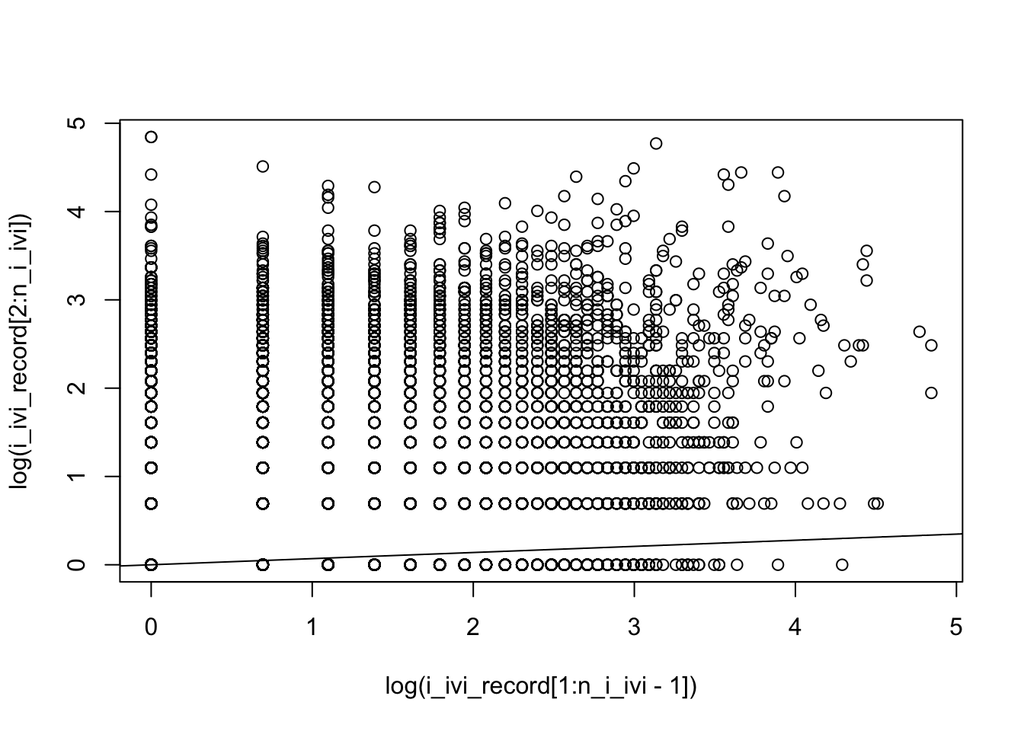

```r
n_i_ivi = length(i_ivi_record)
plot(log(i_ivi_record[1:n_i_ivi-1]),log(i_ivi_record[2:n_i_ivi]))
i_ivi_fit = lm(scale(log(i_ivi_record[2:n_i_ivi]))~scale(log(i_ivi_record[1:n_i_ivi-1])))
#i_ivi_fit = lm(scale(log(i_ivi_record[4:n_i_ivi]))~scale(log(i_ivi_record[1:(n_i_ivi-3)]))+scale(log(i_ivi_record[2:(n_i_ivi-2)]))+scale(log(i_ivi_record[3:(n_i_ivi-1)])))
abline(i_ivi_fit)
```

```r
summary(i_ivi_fit)
```

```
##
## Call:
## lm(formula = scale(log(i_ivi_record[2:n_i_ivi])) ~ scale(log(i_ivi_record[1:n_i_ivi -
##     1])))
##
## Residuals:
##     Min      1Q  Median      3Q     Max
## -1.7289 -0.7755  0.0036  0.7437  3.4662
##
## Coefficients:
##                                          Estimate Std. Error t value Pr(>|t|)
## (Intercept)                             1.552e-16  1.437e-02   0.000        1
## scale(log(i_ivi_record[1:n_i_ivi - 1])) 6.971e-02  1.437e-02   4.849 1.28e-06
##
## (Intercept)
## scale(log(i_ivi_record[1:n_i_ivi - 1])) ***
## ---
## Signif. codes:  0 '***' 0.001 '**' 0.01 '*' 0.05 '.' 0.1 ' ' 1
##
## Residual standard error: 0.9977 on 4816 degrees of freedom
## Multiple R-squared:  0.004859,   Adjusted R-squared:  0.004652
## F-statistic: 23.52 on 1 and 4816 DF,  p-value: 1.278e-06
```

## Get the residuals of of that fit, indicating if the current infant IVI is longer or shorter than expected given the previous infant IVI

```r
i_ivi_res = resid(i_ivi_fit)
```

# See if the residuals of the prediction of current IVI based on previous IVI show a pattern where wr IVIs are shorter than wor IVIs controlling for the persistence of IVI

```r
i_ivi_res_fit = lm(scale(i_ivi_res[1:length(i_ivi_res-1)])~scale(i_ivi_wr_record[2:length(i_ivi_wr_record-1)]),na.action=na.omit)
#i_ivi_res_fit = lm(scale(i_ivi_res[1:length(i_ivi_res-1)])~scale(i_ivi_wr_record[4:length(i_ivi_wr_record-1)]),na.action=na.omit)
summary(i_ivi_res_fit)
```

```
##
## Call:
## lm(formula = scale(i_ivi_res[1:length(i_ivi_res - 1)]) ~ scale(i_ivi_wr_record[2:length(i_ivi_wr_record -
##     1)]), na.action = na.omit)
##
## Residuals:
##      Min       1Q   Median       3Q      Max
## -1.36964 -0.68965 -0.05325  0.58549  3.15185
##
## Coefficients:
##                                                       Estimate Std. Error
## (Intercept)                                            0.28138    0.01278
## scale(i_ivi_wr_record[2:length(i_ivi_wr_record - 1)]) -0.08727    0.01278
##                                                       t value Pr(>|t|)
## (Intercept)                                             22.02  < 2e-16 ***
## scale(i_ivi_wr_record[2:length(i_ivi_wr_record - 1)])   -6.83 9.77e-12 ***
## ---
## Signif. codes:  0 '***' 0.001 '**' 0.01 '*' 0.05 '.' 0.1 ' ' 1
##
## Residual standard error: 0.8152 on 4069 degrees of freedom
##   (747 observations deleted due to missingness)
## Multiple R-squared:  0.01133,    Adjusted R-squared:  0.01109
## F-statistic: 46.64 on 1 and 4069 DF,  p-value: 9.773e-12
```